# Regex

# Text Mining

There are quite a number of R packages for doing text mining. For example,

- tm
- quanteda
- tidytext
- corpus
- koRpus

See here for a nice comparison between the packages: https://quanteda.io/articles/pkgdown/comparison.html

We will focus on `tidytext` for its simplicity.

So what do we do with text mining?

(from https://www.linguamatics.com/) > Text mining (also referred to as text analytics) is an artificial intelligence (AI) technology that uses natural language processing (NLP) to transform the free (unstructured) text in documents and databases into normalized, structured data suitable for analysis or to drive machine learning (ML) algorithms.

(Disclaimer: I am not an expert of NLP or text mining)

Text data often are stored in the following ways

- String: Text can, of course, be stored as strings, i.e., character vectors, within R, and often text data is first read into memory in this form.
- Corpus: These types of objects typically contain raw strings annotated with additional metadata and details.
- Document-term matrix: This is a sparse matrix describing a collection (i.e., a corpus) of documents with one row for each document and one column for each term. The value in the matrix is typically word count or `tf-idf`

```r
library(tidyverse)
library(tidytext)
```

```r
# A poem by Emily Dickinson
text <- c("Because I could not stop for Death -",
          "He kindly stopped for me -",
          "The Carriage held but just Ourselves -",
          "and Immortality")
df <- tibble(line = 1:4, text = text)
```

We want to convert the data frame so that it has one-token-per-document-per-row.

```r
df %>%
  unnest_tokens(word, text)
```

```
## # A tibble: 20 x 2
##     line word
##    <int> <chr>
##  1     1 because
##  2     1 i
##  3     1 could
##  4     1 not
##  5     1 stop
##  6     1 for
##  7     1 death
##  8     2 he
##  9     2 kindly
## 10     2 stopped
## 11     2 for
## 12     2 me
## 13     3 the
## 14     3 carriage
## 15     3 held
## 16     3 but
## 17     3 just
## 18     3 ourselves
## 19     4 and
## 20     4 immortality
```

After using `unnest_tokens`, we’ve split each row so that there is one token (word) in each row of the new data frame; the default tokenization in `unnest_tokens()` is for single words (unigram), as shown here. Also notice:

- Other columns, such as the line number each word came from, are retained.
- Punctuation has been stripped.
- By default, `unnest_tokens()` converts the tokens to lowercase, which makes them easier to compare or combine with other datasets. (Use the `to_lower = FALSE` argument to turn off this behavior).

Often in text analysis, we will want to remove stop words; stop words are words that are not useful for an analysis, typically extremely common words such as “the”, “of”, “to”, and so forth in English.

```r
data(stop_words)
stop_words
```

```
## # A tibble: 1,149 x 2
##    word        lexicon
##    <chr>       <chr>
##  1 a           SMART
##  2 a's         SMART
##  3 able        SMART
##  4 about       SMART
##  5 above       SMART
##  6 according   SMART
##  7 accordingly SMART
##  8 across      SMART
##  9 actually    SMART
## 10 after       SMART
## # … with 1,139 more rows
```

```r
df %>%
  unnest_tokens(word, text) %>%
  anti_join(stop_words)
```

```
## # A tibble: 7 x 2
##    line word
##   <int> <chr>
## 1     1 stop
## 2     1 death
## 3     2 kindly
## 4     2 stopped
## 5     3 carriage
## 6     3 held
## 7     4 immortality
```

```r
library(rvest)
```

Try to read some news headlines from yahoo

```r
h3 <- read_html("http://news.yahoo.com/") %>%
  html_nodes("h3")

news_df <- tibble(
    title = h3 %>% html_text(),
    url = h3 %>%  html_node("a") %>% html_attr("href")
  ) %>%
  filter(str_starts(url, "https://news.yahoo.com/")) %>%
  mutate(id = sprintf("%02d", row_number())) %>%
  head(20)
```

Read the contents

```r
news_content <- NULL
for (i in seq_len(nrow(news_df))) {
  news_content <- bind_rows(
    news_content,
    read_html(news_df$url[i]) %>%
      html_nodes("article p") %>%
      html_text() %>% {
        tibble(id = news_df$id[i], text = c(news_df$title[i], .))
      }
  )
}
```

```r
news_tokens <- news_content %>%
  unnest_tokens(word, text) %>%
  anti_join(stop_words) %>%
  group_by(id) %>%
  count(word, sort = TRUE) %>%
  arrange(id)
```

Use relative frequencies

```r
(news_propotions <- news_tokens %>%
  group_by(id) %>%
  mutate(propotion = n / sum(n)) %>%
  select(-n) %>%
  arrange(id, desc(propotion)))
```

```
## # A tibble: 4,708 x 3
## # Groups:   id [20]
##    id    word     propotion
##    <chr> <chr>        <dbl>
##  1 01    church      0.0394
##  2 01    people      0.0215
##  3 01    budde       0.0179
##  4 01    john’s      0.0179
##  5 01    st          0.0179
##  6 01    monday      0.0143
##  7 01    building    0.0125
##  8 01    police      0.0125
##  9 01    protests    0.0125
## 10 01    trump       0.0125
## # … with 4,698 more rows
```

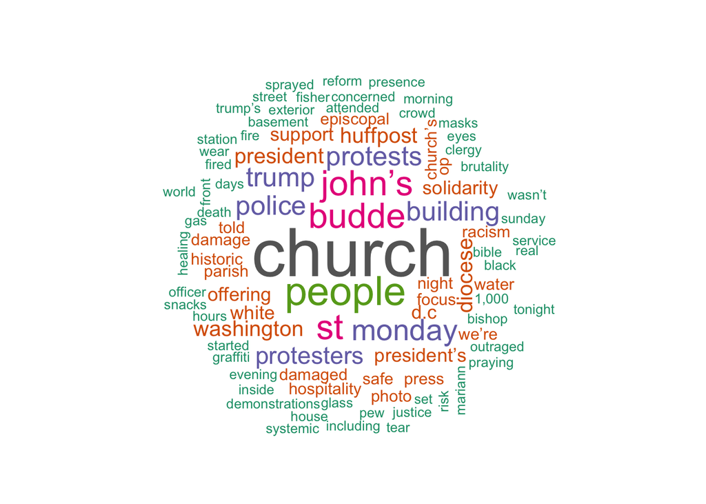

```r
library(wordcloud)
news_tokens %>%
  filter(id == "01") %>%
  with(wordcloud(
    word, n, min.freq = 2, max.words = 100, random.order = FALSE,
    colors = brewer.pal(8, "Dark2")))
```

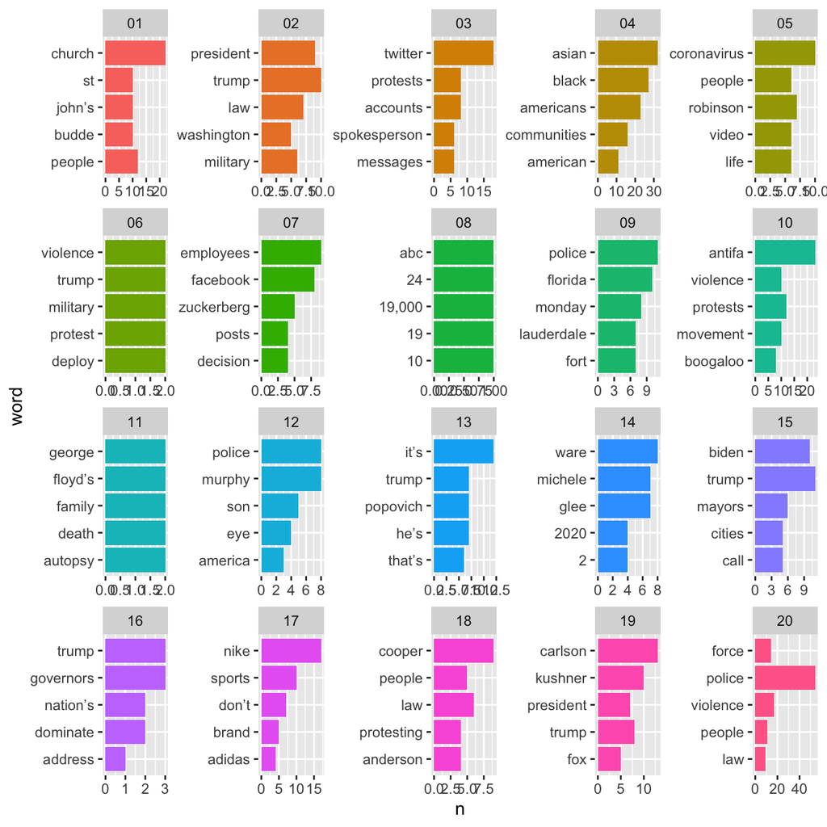

```r
news_tokens %>%
  slice_max(n, n = 5, with_ties = FALSE) %>%
  ggplot(aes(x = fct_reorder(word, n), y = n, fill = id)) +
      geom_bar(stat = "identity", na.rm = TRUE, show.legend = FALSE) +
      xlab("word") +
      facet_wrap(~id, scales = "free") +
      coord_flip()
```

The order the categories in each facet are not ordered correctly. Following https://drsimonj.svbtle.com/ordering-categories-within-ggplot2-facets, I got the following fix.

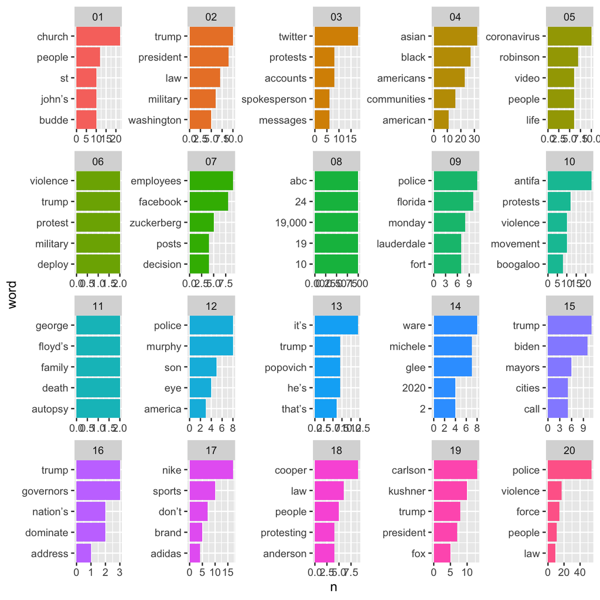

```r
news_tokens %>%
  slice_max(n, n = 5, with_ties = FALSE) %>%
  ungroup() %>%
  arrange(id, n) %>%
  mutate(order = row_number()) %>% {
    ggplot(., aes(x = order, y = n, fill = id)) +
      geom_bar(stat = "identity", na.rm = TRUE, show.legend = FALSE) +
      xlab("word") +
      facet_wrap(~id, scales = "free") +
      coord_flip() +
      scale_x_continuous(breaks = .$order, labels = .$word, expand = c(0, 0))
  }
```

## Sentiment analysis

The `tidytext` package contains several sentiment lexicons. Three general-purpose lexicons are

- `AFINN` from Finn Årup Nielsen,
- `bing` from Bing Liu and collaborators, and
- `nrc` from Saif Mohammad and Peter Turney.

All three of these lexicons are based on unigrams, i.e., single words. These lexicons contain many English words and the words are assigned scores for positive/negative sentiment, and also possibly emotions like joy, anger, sadness, and so forth. It is important to keep in mind that these methods do not take into account qualifiers before a word, such as in “no good” or “not true”; a lexicon-based method like this is based on unigrams only.

```r
library(textdata)

get_sentiments("afinn")
```

```
## # A tibble: 2,477 x 2
##    word       value
##    <chr>      <dbl>
##  1 abandon       -2
##  2 abandoned     -2
##  3 abandons      -2
##  4 abducted      -2
##  5 abduction     -2
##  6 abductions    -2
##  7 abhor         -3
##  8 abhorred      -3
##  9 abhorrent     -3
## 10 abhors        -3
## # … with 2,467 more rows
```

```r
get_sentiments("bing")
```

```
## # A tibble: 6,786 x 2
##    word        sentiment
##    <chr>       <chr>
##  1 2-faces     negative
##  2 abnormal    negative
##  3 abolish     negative
##  4 abominable  negative
##  5 abominably  negative
##  6 abominate   negative
##  7 abomination negative
##  8 abort       negative
##  9 aborted     negative
## 10 aborts      negative
## # … with 6,776 more rows
```

```r
get_sentiments("nrc")
```

```
## # A tibble: 13,901 x 2
##    word        sentiment
##    <chr>       <chr>
##  1 abacus      trust
##  2 abandon     fear
##  3 abandon     negative
##  4 abandon     sadness
##  5 abandoned   anger
##  6 abandoned   fear
##  7 abandoned   negative
##  8 abandoned   sadness
##  9 abandonment anger
## 10 abandonment fear
## # … with 13,891 more rows
```

```r
news_tokens %>%
  left_join(get_sentiments("bing")) %>%
  group_by(id) %>%
  summarize(  # the frequencies are ignored in this analysis
    positive = sum(sentiment == "positive", na.rm = TRUE),
    negative = sum(sentiment == "negative", na.rm = TRUE),
    netural = n() - positive - negative) %>%
  mutate(
    id,
    sentiment = case_when(
      positive > negative ~ "positive",
      positive < negative ~ "negative",
      TRUE ~ "netural"
    )
  ) %>%
  left_join(select(news_df, id, title)) %>%
  mutate(title = str_trunc(title, 80)) %>%
  select(sentiment, title)
```

```
## # A tibble: 20 x 2
##    sentiment title
##    <chr>     <chr>
##  1 negative  "D.C. Church 'Outraged' That Trump Used It As Photo-Op"
##  2 negative  "Trump says he will use military to put down riots"
##  3 negative  "White nationalist group posing as antifa called for violence on T…
##  4 negative  "The officer who stood by as George Floyd died is Asian American. …
##  5 negative  "'The world is scared right now': 16-year-old boys create short fi…
##  6 netural   " ‘We will end it now’: Trump says he will deploy military if stat…
##  7 negative  "Facebook staff plan 'virtual walkout' over response to Trump post…
##  8 positive  "More than 19,000 new COVID-19 cases in US over past 24 hours"
##  9 negative  "Florida police officer suspended for pushing kneeling woman"
## 10 negative  "Violent protests shine spotlight on extremists, from antifa to 'B…
## 11 negative  "George Floyd’s family releases results of independent autopsy int…
## 12 negative  "Dale Murphy says cop shot his son in face with rubber bullet as h…
## 13 negative  "Gregg Popovich unleashes fiery statement on Trump: 'What we have …
## 14 negative  "Lea Michele Accused of Making ‘Glee’ a ‘Living Hell’ for Co-Star …
## 15 negative  "Trump, Biden strike different tones on calls with local, state le…
## 16 negative  "Trump calls nation’s governors ‘weak,' demands they crack down on…
## 17 negative  "Nike is setting the tone for sports brands in its response to the…
## 18 negative  "Anderson Cooper Tears Into Donald Trump’s “Law And Order” Approac…
## 19 negative  "Tucker Carlson Blames Jared Kushner for Trump’s Protest Catastrop…
## 20 negative  "How can police violence be prevented?"
```

## Analyzing word and document frequency: tf-idf

A central question in text mining and natural language processing is how to quantify what a document is about. One measure of how important a word may be is its term frequency. Another approach is to look at a term’s inverse document frequency (idf), which decreases the weight for commonly used words and increases the weight for words that are not used very much.

$$\text{idf} = \ln\left(\frac{n_{\text{documents}}}{n_{\text{documents containing term}}} \right)$$

$$\text{tf_idf} = \text{tf} \times \text{idf}$$

Show the 3 most important words in each document.

```r
news_tokens %>%
  bind_tf_idf(word, id, n) %>%
  slice_max(tf_idf, n = 3) %>%
  select(id, word, n, tf_idf)
```

```
## # A tibble: 69 x 4
## # Groups:   id [20]
##    id    word          n tf_idf
##    <chr> <chr>     <int>  <dbl>
##  1 01    church       22 0.0633
##  2 01    budde        10 0.0412
##  3 01    john’s       10 0.0412
##  4 02    military      6 0.0186
##  5 02    johns         2 0.0154
##  6 02    requested     2 0.0154
##  7 02    restore       2 0.0154
##  8 02    starts        2 0.0154
##  9 02    thousands     2 0.0154
## 10 02    urging        2 0.0154
## # … with 59 more rows
```

Using term frequency and inverse document frequency allows us to find words that are characteristic for one document within a collection of documents.

## n-grams

We’ve been using the unnest_tokens function to tokenize by word, or sometimes by sentence, which is useful for the kinds of sentiment and frequency analyses we’ve been doing so far. But we can also use the function to tokenize into consecutive sequences of words, called n-grams.

## Using bigrams to provide context in sentiment analysis

Our sentiment analysis approach above simply counted the appearance of positive or negative words. One of the problems with this approach is that a word’s context can matter nearly as much as its presence. For example, the words “happy” and “like” will be counted as positive, even in a sentence like “I’m not happy and I don’t like it!”

```r
# stop words are not removed in this case
news_tokens2 <- news_content %>%
  unnest_tokens(bigram, text, token = "ngrams", n = 2) %>%
  separate(bigram, c("word1", "word2"), sep = " ")
```

Back to the sentiment analysis

```r
negate_words <- c("not", "without", "no", "can't", "don't", "won't")

news_tokens2 %>%
  group_by(id) %>%
  count(word1, word2) %>%
  left_join(get_sentiments("bing"), by = c("word2" = "word")) %>%
  mutate(sentiment = case_when(
    word1 %in% negate_words & sentiment == "negative" ~ "positive",
    word1 %in% negate_words & sentiment == "positive" ~ "negative",
    TRUE ~ sentiment)) %>%
  summarize(
    positive = sum(sentiment == "positive", na.rm = TRUE),
    negative = sum(sentiment == "negative", na.rm = TRUE),
    netural = n() - positive - negative) %>%
  mutate(
    id,
    sentiment = case_when(
      positive > negative ~ "positive",
      positive < negative ~ "negative",
      TRUE ~ "netural"
    )
  ) %>%
  left_join(select(news_df, id, title)) %>%
  mutate(title = str_trunc(title, 80)) %>%
  select(sentiment, title)
```

```
## # A tibble: 20 x 2
##    sentiment title
##    <chr>     <chr>
##  1 negative  "D.C. Church 'Outraged' That Trump Used It As Photo-Op"
##  2 negative  "Trump says he will use military to put down riots"
##  3 negative  "White nationalist group posing as antifa called for violence on T…
##  4 negative  "The officer who stood by as George Floyd died is Asian American. …
##  5 positive  "'The world is scared right now': 16-year-old boys create short fi…
##  6 positive  " ‘We will end it now’: Trump says he will deploy military if stat…
##  7 negative  "Facebook staff plan 'virtual walkout' over response to Trump post…
##  8 netural   "More than 19,000 new COVID-19 cases in US over past 24 hours"
##  9 negative  "Florida police officer suspended for pushing kneeling woman"
## 10 negative  "Violent protests shine spotlight on extremists, from antifa to 'B…
## 11 negative  "George Floyd’s family releases results of independent autopsy int…
## 12 negative  "Dale Murphy says cop shot his son in face with rubber bullet as h…
## 13 negative  "Gregg Popovich unleashes fiery statement on Trump: 'What we have …
## 14 positive  "Lea Michele Accused of Making ‘Glee’ a ‘Living Hell’ for Co-Star …
## 15 negative  "Trump, Biden strike different tones on calls with local, state le…
## 16 negative  "Trump calls nation’s governors ‘weak,' demands they crack down on…
## 17 negative  "Nike is setting the tone for sports brands in its response to the…
## 18 negative  "Anderson Cooper Tears Into Donald Trump’s “Law And Order” Approac…
## 19 negative  "Tucker Carlson Blames Jared Kushner for Trump’s Protest Catastrop…
## 20 negative  "How can police violence be prevented?"
```

## Cluster analysis

> Cluster analysis or clustering is the task of grouping a set of objects in such a way that objects in the same group (called a cluster) are more similar (in some sense) to each other than to those in other groups (clusters)

First, we will need to define similarity. One way to quantity how similar two documents are is the cosine distance.

Compare to regular euclidean distance, it is more situable for sparse vectors.

```r
library(proxy)
docsdissim <- dist(as.matrix(cast_dtm(news_tokens, id, word, n)), method = "cosine")
```

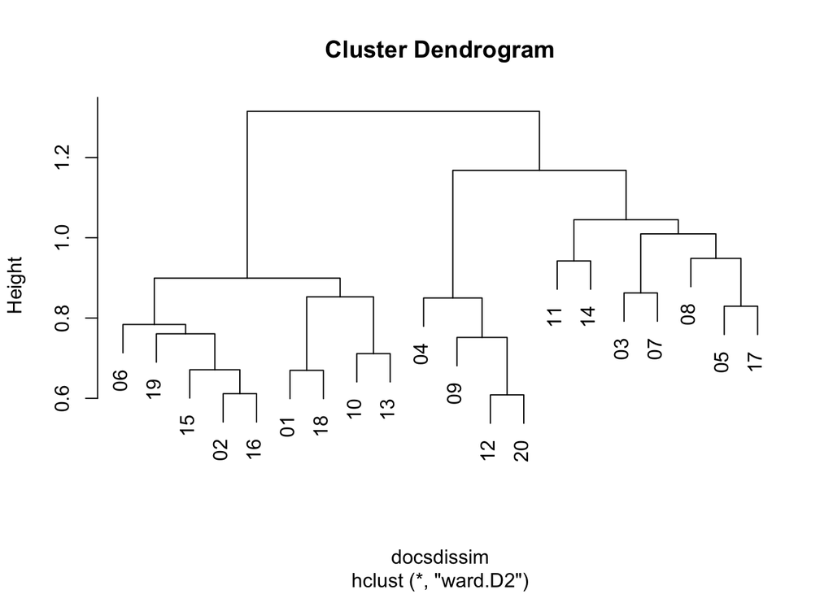

```r
h <- hclust(docsdissim, method = "ward.D2")
plot(h)
```

We could use `cutree` to pick the number of groups.

```r
tibble(topic = cutree(h, k = 3), title = news_df$title) %>%
  arrange(topic) %>%
  mutate(title = str_trunc(title, 80)) %>%
  select(topic, title)
```

```
## # A tibble: 20 x 2
##    topic title
##    <int> <chr>
##  1     1 "D.C. Church 'Outraged' That Trump Used It As Photo-Op"
##  2     1 "Trump says he will use military to put down riots"
##  3     1 " ‘We will end it now’: Trump says he will deploy military if states c…
##  4     1 "Violent protests shine spotlight on extremists, from antifa to 'Booga…
##  5     1 "Gregg Popovich unleashes fiery statement on Trump: 'What we have is a…
##  6     1 "Trump, Biden strike different tones on calls with local, state leader…
##  7     1 "Trump calls nation’s governors ‘weak,' demands they crack down on pro…
##  8     1 "Anderson Cooper Tears Into Donald Trump’s “Law And Order” Approach To…
##  9     1 "Tucker Carlson Blames Jared Kushner for Trump’s Protest Catastrophe"
## 10     2 "White nationalist group posing as antifa called for violence on Twitt…
## 11     2 "'The world is scared right now': 16-year-old boys create short film t…
## 12     2 "Facebook staff plan 'virtual walkout' over response to Trump posts"
## 13     2 "More than 19,000 new COVID-19 cases in US over past 24 hours"
## 14     2 "George Floyd’s family releases results of independent autopsy into hi…
## 15     2 "Lea Michele Accused of Making ‘Glee’ a ‘Living Hell’ for Co-Star Sama…
## 16     2 "Nike is setting the tone for sports brands in its response to the Geo…
## 17     3 "The officer who stood by as George Floyd died is Asian American. We n…
## 18     3 "Florida police officer suspended for pushing kneeling woman"
## 19     3 "Dale Murphy says cop shot his son in face with rubber bullet as he pe…
## 20     3 "How can police violence be prevented?"
```

In cluster analysis, we only assign a single topic to a single document. In reality, a single document may contain multiple topics.

## LDA

Latent Dirichlet allocation is one of the most common algorithms for topic modeling. Without diving into the math behind the model, we can understand it as being guided by two principles.

- Every topic is a mixture of words
- Every document is a mixture of topics

```r
library(topicmodels)
```

We want to allocate the topics and documents into 4 different topics.

```r
news_lda <- LDA(
  cast_dtm(news_tokens, id, word, n),
  k = 4,
  control = list(seed = 1234))
```

### Word-topic probabilities

The following table shows the probability of a specific term occurring in a topic.

```r
tidy(news_lda, matrix = "beta") %>%
  group_by(topic) %>%
  top_n(10, beta) %>%
  arrange(topic, desc(beta))
```

```
## # A tibble: 42 x 3
## # Groups:   topic [4]
##    topic term            beta
##    <int> <chr>          <dbl>
##  1     1 twitter      0.0200
##  2     1 nike         0.0162
##  3     1 protests     0.0124
##  4     1 employees    0.00951
##  5     1 sports       0.00951
##  6     1 facebook     0.00856
##  7     1 accounts     0.00856
##  8     1 messages     0.00760
##  9     1 posted       0.00760
## 10     1 spokesperson 0.00665
## # … with 32 more rows
```

### Document-topic probabilities

The following table shows the probability of a specific topic occurring in a document.

```r
# t is the variable `alpha` on the wikipedia page of LDA
tidy(news_lda, matrix = "gamma") %>%
    pivot_wider(names_from = topic, values_from = gamma)
```

```
## # A tibble: 20 x 5
##    document       `1`       `2`       `3`       `4`
##    <chr>        <dbl>     <dbl>     <dbl>     <dbl>
##  1 01       0.0000404 1.00      0.0000404 0.0000404
##  2 02       0.0000582 0.0000582 1.00      0.0000582
##  3 03       1.00      0.0000512 0.0000512 0.0000512
##  4 04       0.0000234 0.0000234 0.0000234 1.00
##  5 05       0.0000602 1.00      0.0000602 0.0000602
##  6 06       0.00150   0.00150   0.996     0.00150
##  7 07       1.00      0.000141  0.000141  0.000141
##  8 08       0.00118   0.00118   0.996     0.00118
##  9 09       0.0000538 1.00      0.0000538 0.0000538
## 10 10       0.0000344 0.0000344 1.00      0.0000344
## 11 11       0.997     0.000978  0.000978  0.000978
## 12 12       0.0000969 1.00      0.0000969 0.0000969
## 13 13       0.0000740 0.0000740 1.00      0.0000740
## 14 14       0.000104  1.00      0.000104  0.000104
## 15 15       0.0000552 0.0000552 1.00      0.0000552
## 16 16       0.000578  0.000578  0.998     0.000578
## 17 17       1.00      0.0000528 0.0000528 0.0000528
## 18 18       0.000112  0.000112  1.00      0.000112
## 19 19       0.0000784 0.0000784 1.00      0.0000784
## 20 20       0.0000268 0.0000268 0.0000268 1.00
```

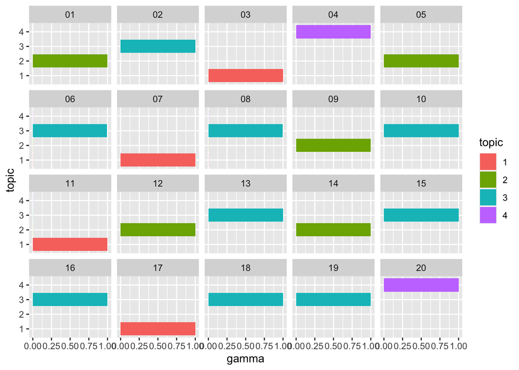

```r
tidy(news_lda, "gamma") %>%
  mutate(topic = as_factor(topic)) %>%
  ggplot(aes(topic, gamma, fill = topic)) +
  geom_bar(stat = "identity") +
  facet_wrap(~document, 4) +
  coord_flip()
```

## CTM

Correlated topic model is an extension of LDA which supports correlations between topics.

```r
news_ctm <- CTM(
  cast_dtm(news_tokens, id, word, n),
  k = 4,
  control = list(seed = 1234) )
```

```r
tidy(news_ctm, matrix = "beta") %>%
  group_by(topic) %>%
  top_n(10, beta) %>%
  arrange(topic, desc(beta))
```

```
## # A tibble: 40 x 3
## # Groups:   topic [4]
##    topic term          beta
##    <int> <chr>        <dbl>
##  1     1 trump      0.0171
##  2     1 church     0.0150
##  3     1 president  0.0105
##  4     1 nike       0.00913
##  5     1 people     0.00907
##  6     1 protests   0.00840
##  7     1 st         0.00805
##  8     1 protesters 0.00706
##  9     1 police     0.00648
## 10     1 budde      0.00644
## # … with 30 more rows
```

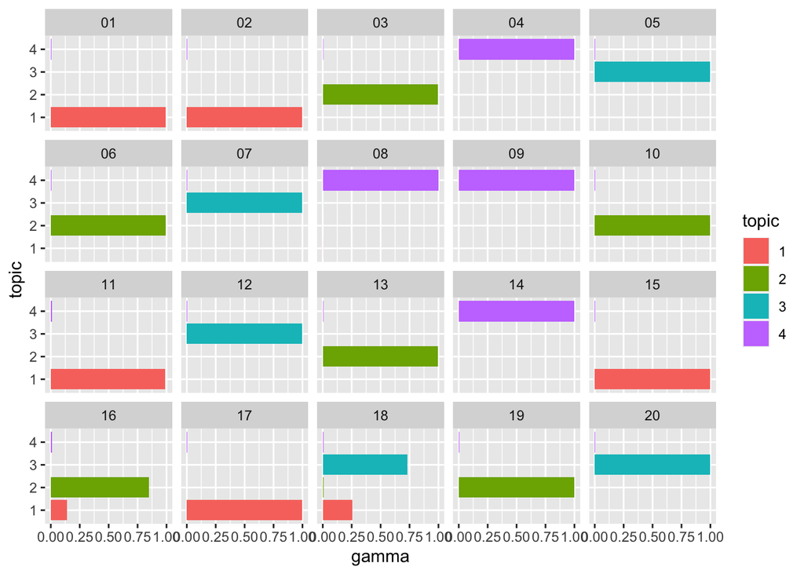

```r
tidy(news_ctm, "gamma") %>%
  mutate(topic = as_factor(topic)) %>%
  ggplot(aes(topic, gamma, fill = topic)) +
  geom_bar(stat = "identity") +
  facet_wrap(~document, 4) +
  coord_flip()
```

# Reference:

- Tidytext: https://www.tidytextmining.com/